# STA 141A Project 2

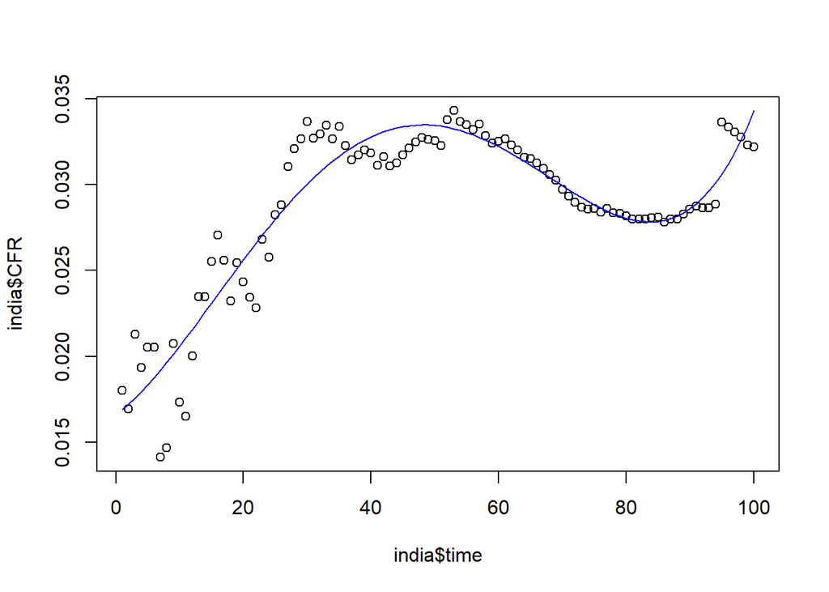

##Indonesia Model

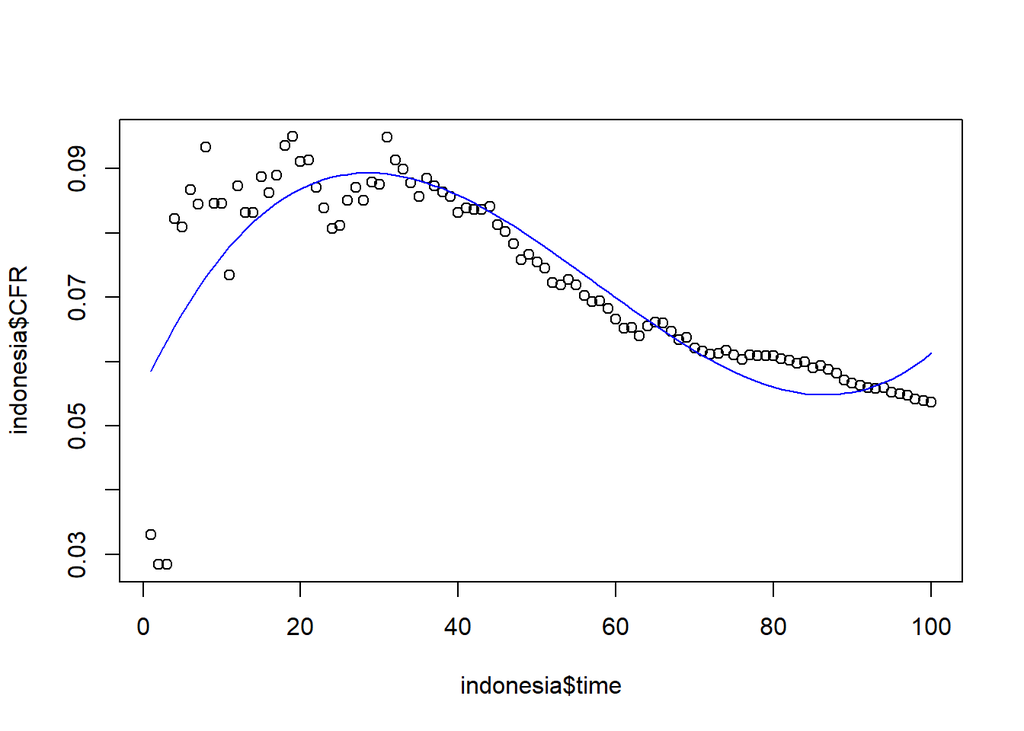

##Pakistan Model

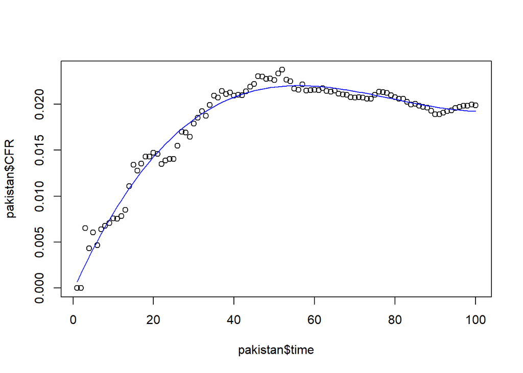

##Russia Model

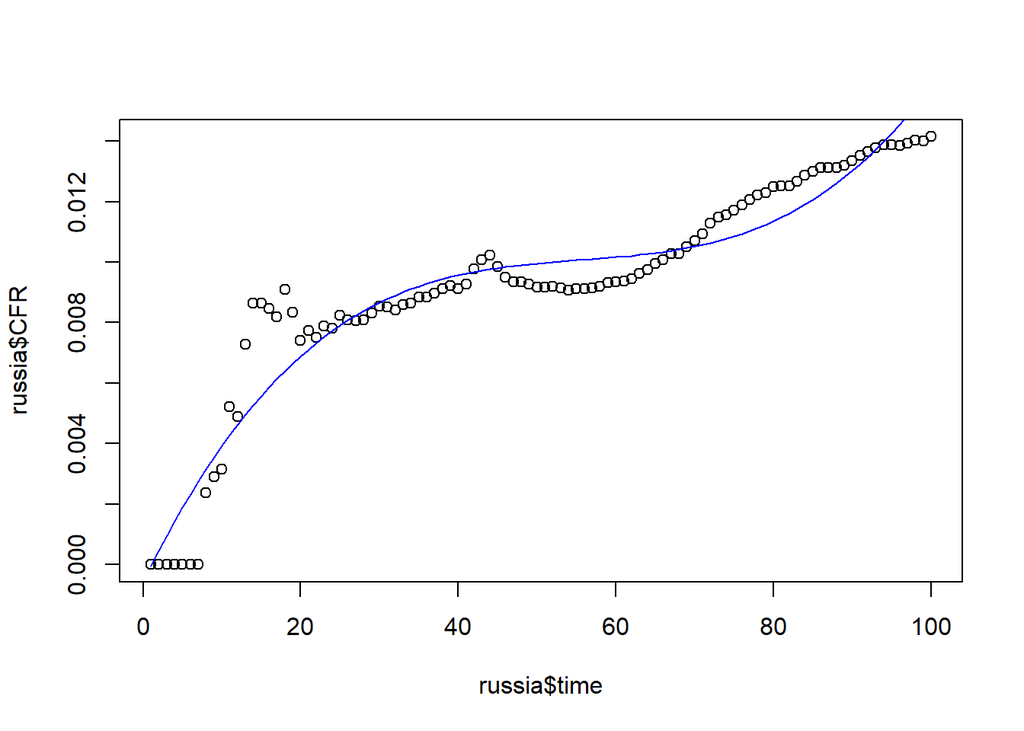

##Turkey Model

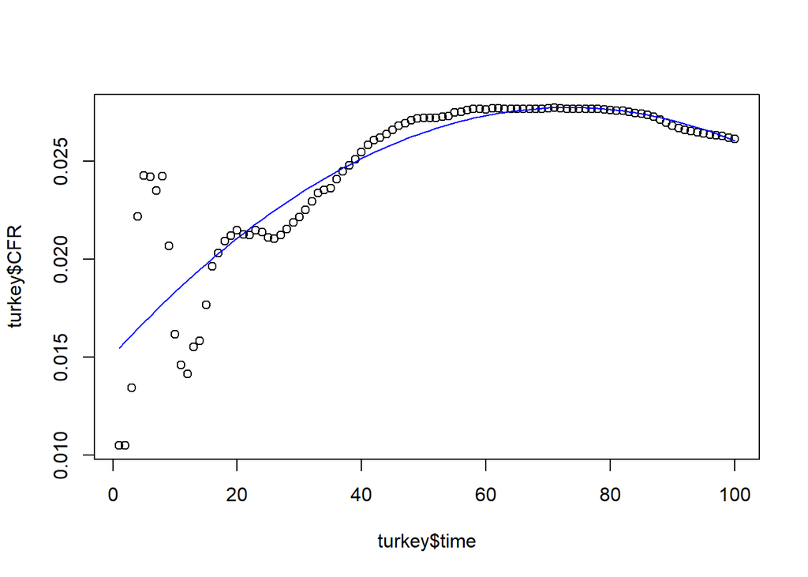

##Egypt Model

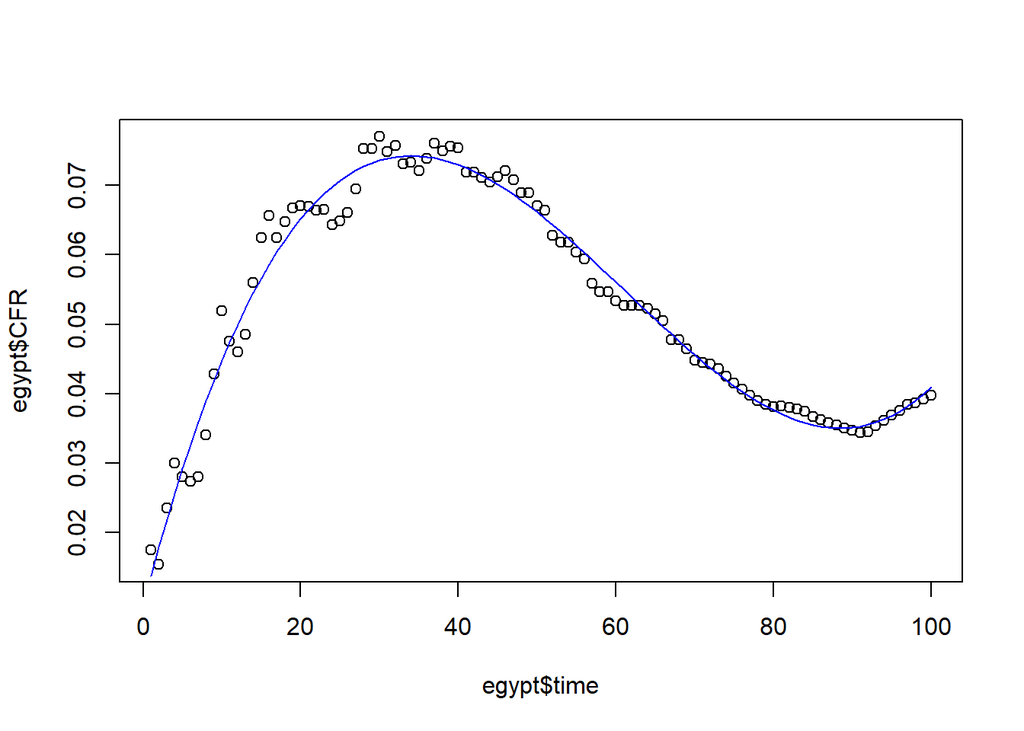

##Japan Model

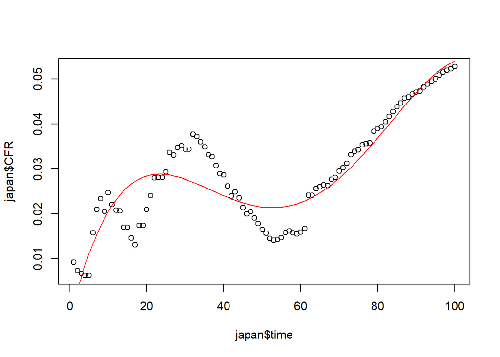

##China Model

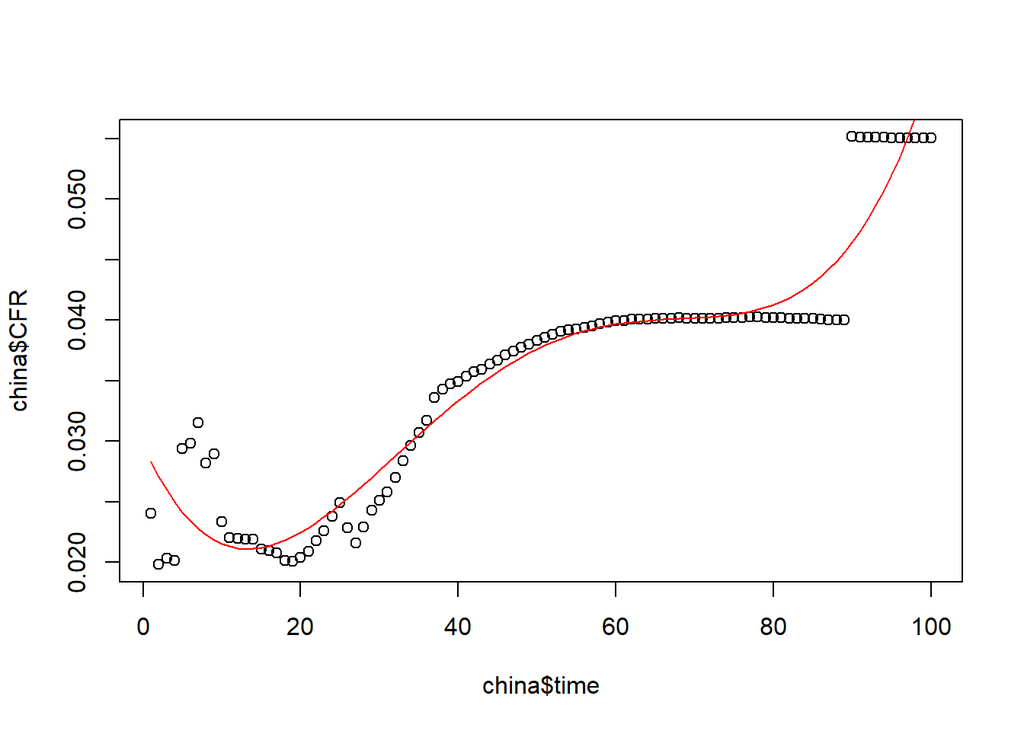

# Results

For an actual answer to our question of interest, there will be two approaches to reach suitable results: ANOVA, and confidence bands.

In the following ANOVA models, data across all 12 countries will be fit into a regression of a certain polynomial, the same data set will then be fit into the same level of polynomial but with regards to each country. ANOVA will attempt to compare the two regression models to prove if country does have an effect on CFR over time.

Since this type of ANOVA model can only use one chosen degree of polynomials, the third and fourth degree will be tested since they are the most common regressions fitted above.

```
## Analysis of Variance Table
##
## Model 1: CFR ~ poly(time, 3)
## Model 2: CFR ~ poly(time, 3) * Country
##   Res.Df     RSS Df Sum of Sq      F    Pr(>F)
## 1   1196 0.48026
## 2   1152 0.01970 44   0.46057 612.15 < 2.2e-16 ***
## ---
## Signif. codes:  0 '***' 0.001 '**' 0.01 '*' 0.05 '.' 0.1 ' ' 1
```

```
## Analysis of Variance Table
##
## Model 1: CFR ~ poly(time, 4)
## Model 2: CFR ~ poly(time, 4) * Country
##   Res.Df     RSS Df Sum of Sq      F    Pr(>F)
## 1   1195 0.48026
## 2   1140 0.01311 55   0.46715 738.38 < 2.2e-16 ***
## ---
## Signif. codes:  0 '***' 0.001 '**' 0.01 '*' 0.05 '.' 0.1 ' ' 1
```

As shown, the p-value is extremely low for both comparisons. This means that country does have an strong statistical effect on CFR over time for both regressions of third and fourth degree.

# Sensitivity Analysis

##Nigeria Plots

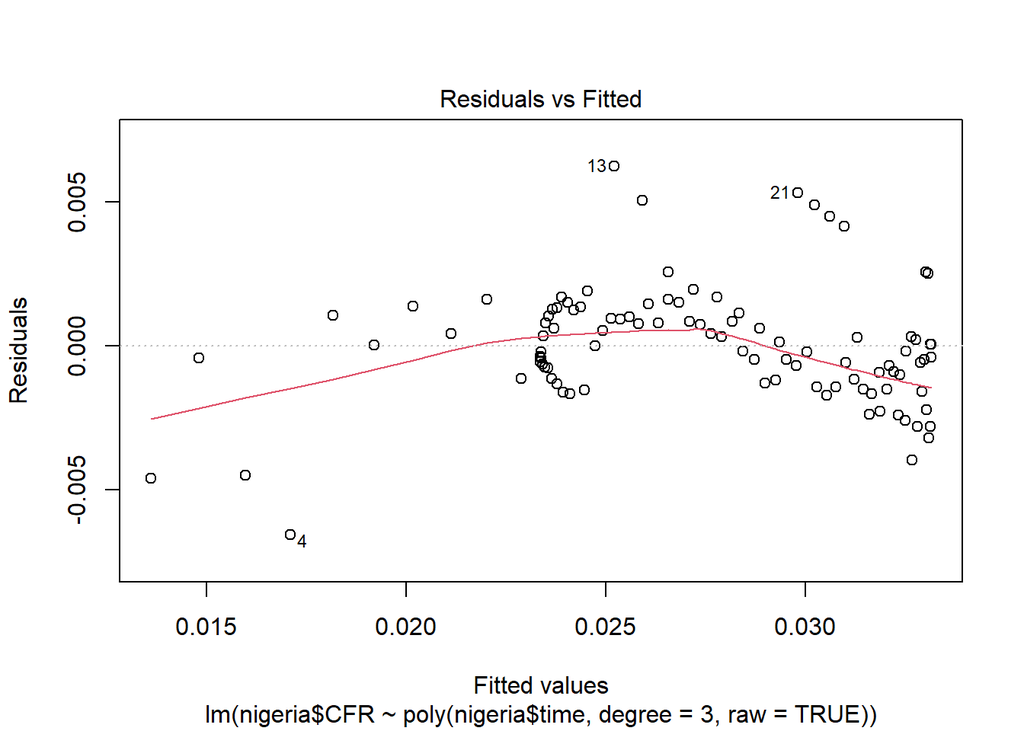

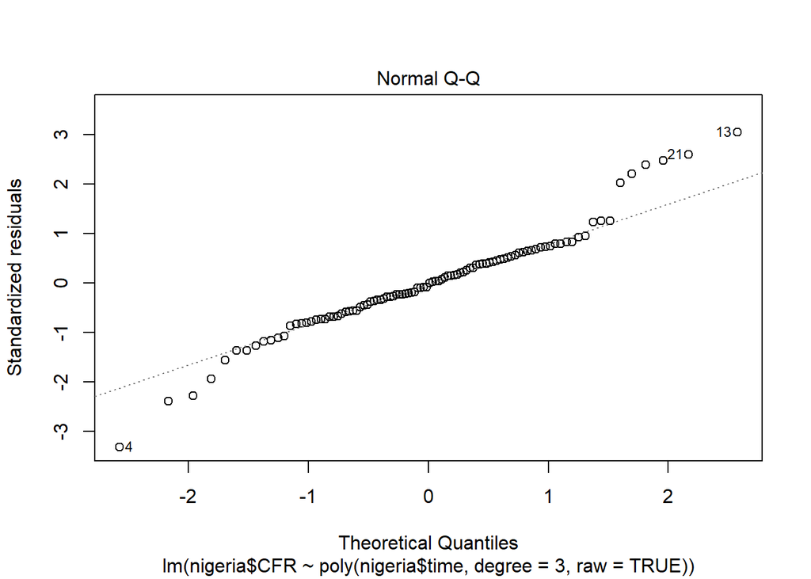

##Ethiopia Plots

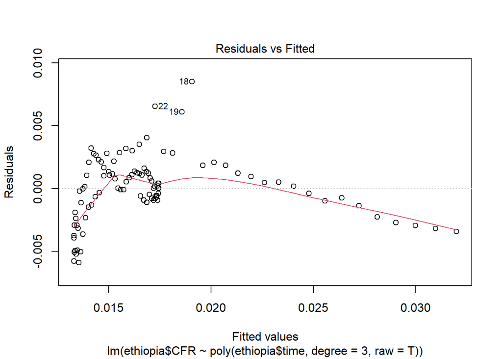

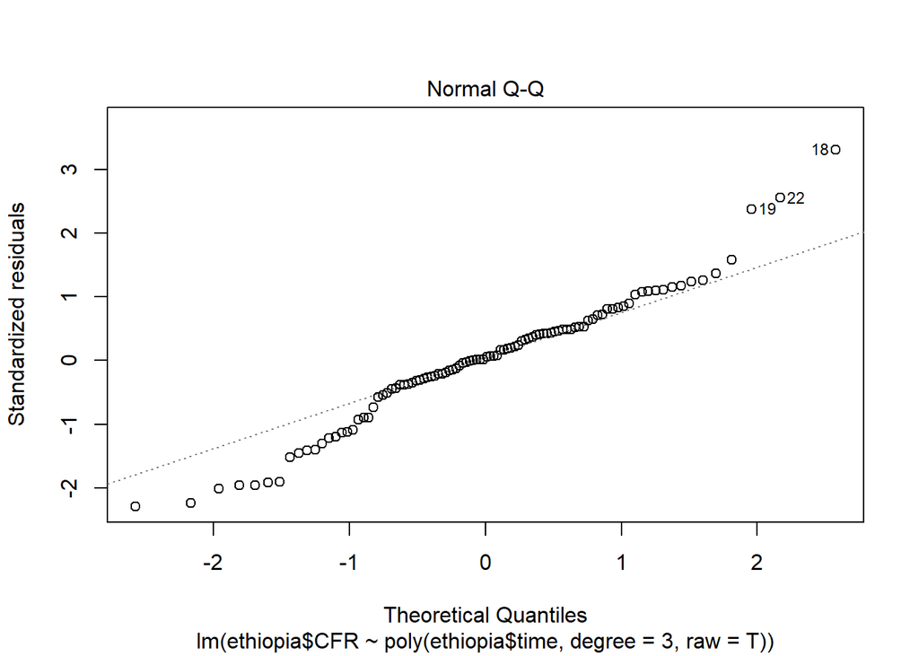

##USA Plots

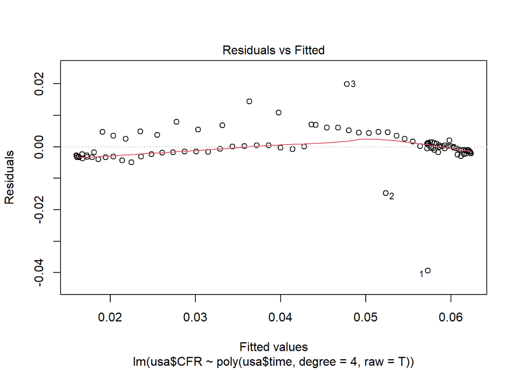

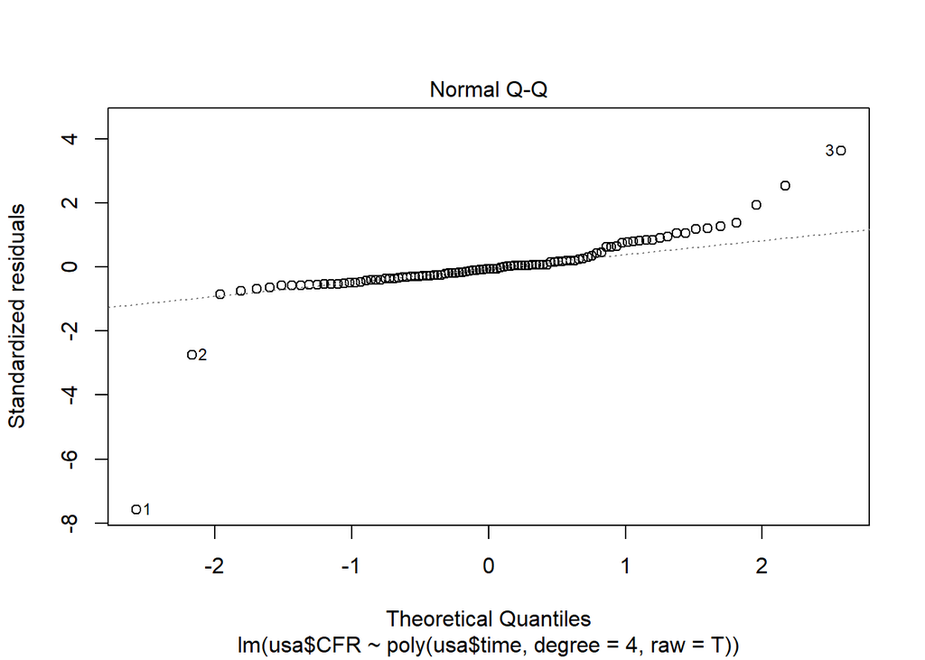

##Brazil Plots

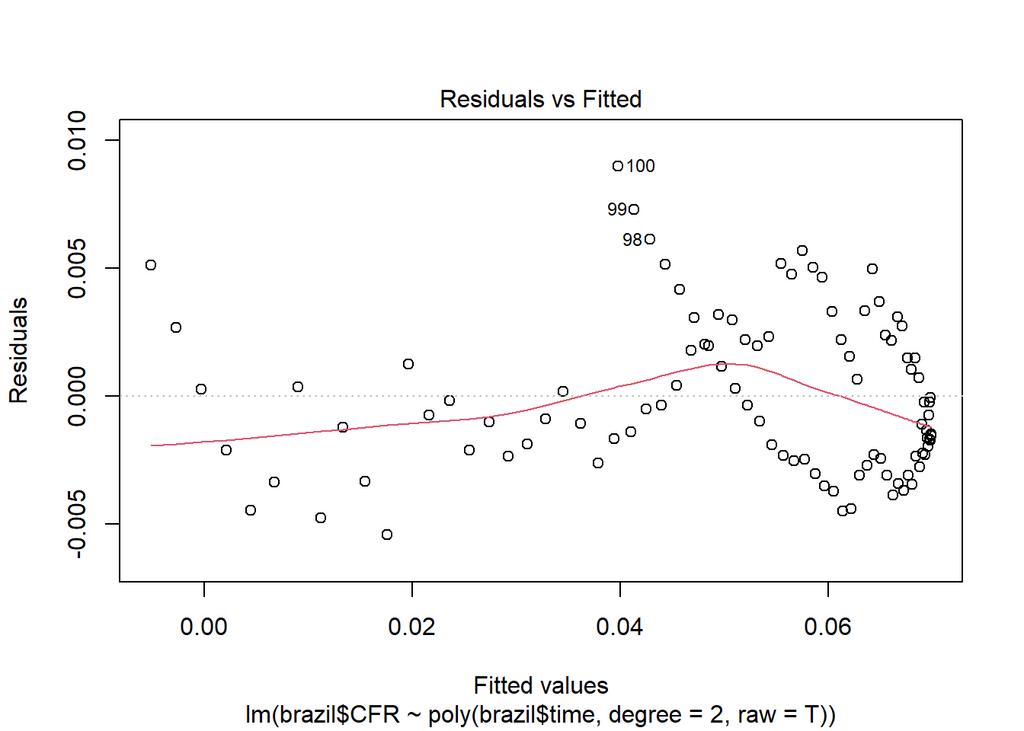

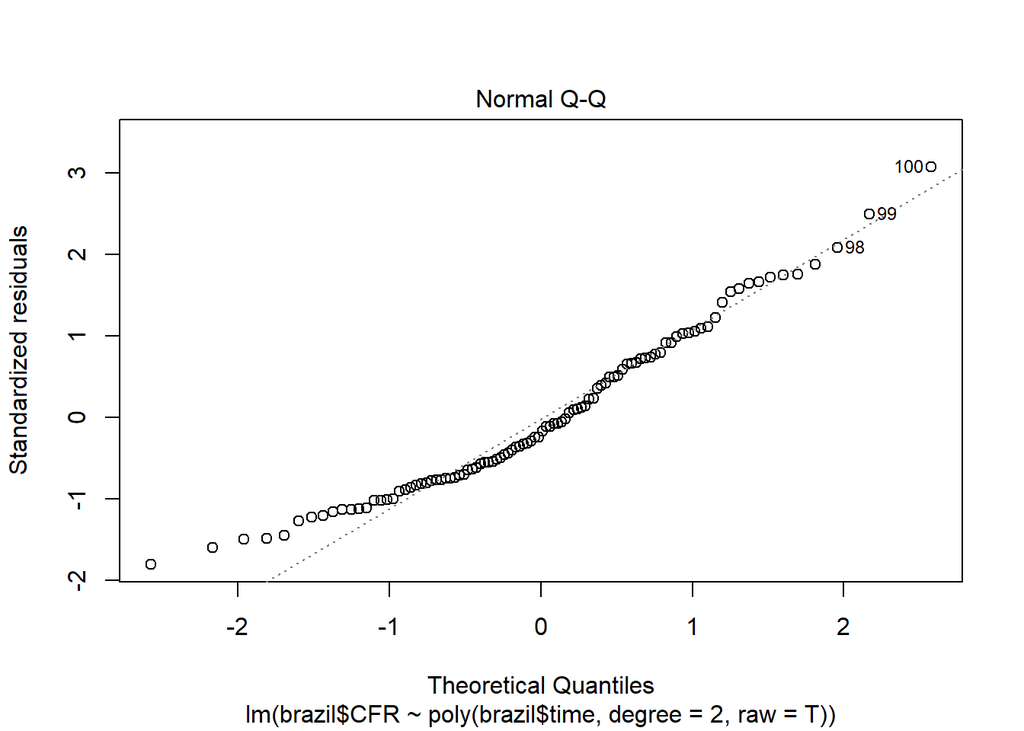

##India Plots

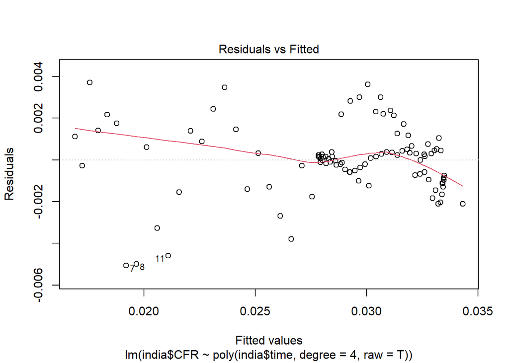

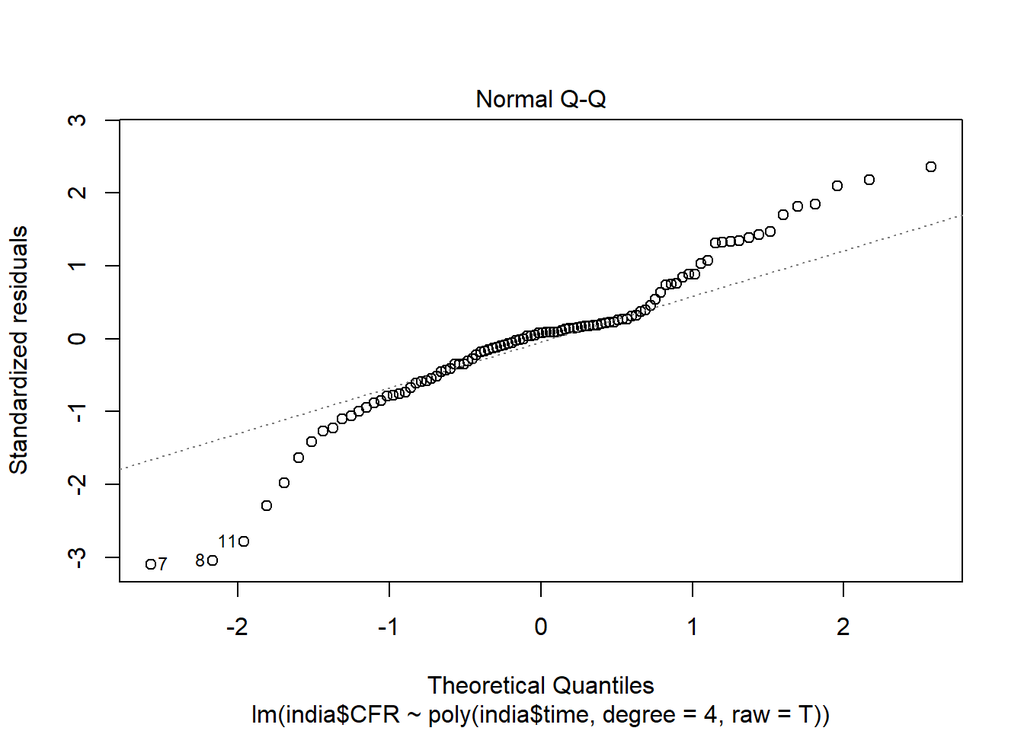

##Indonesia Plots

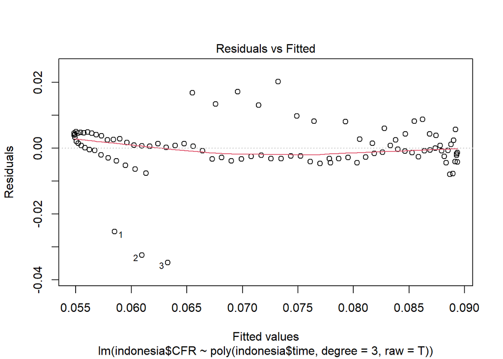

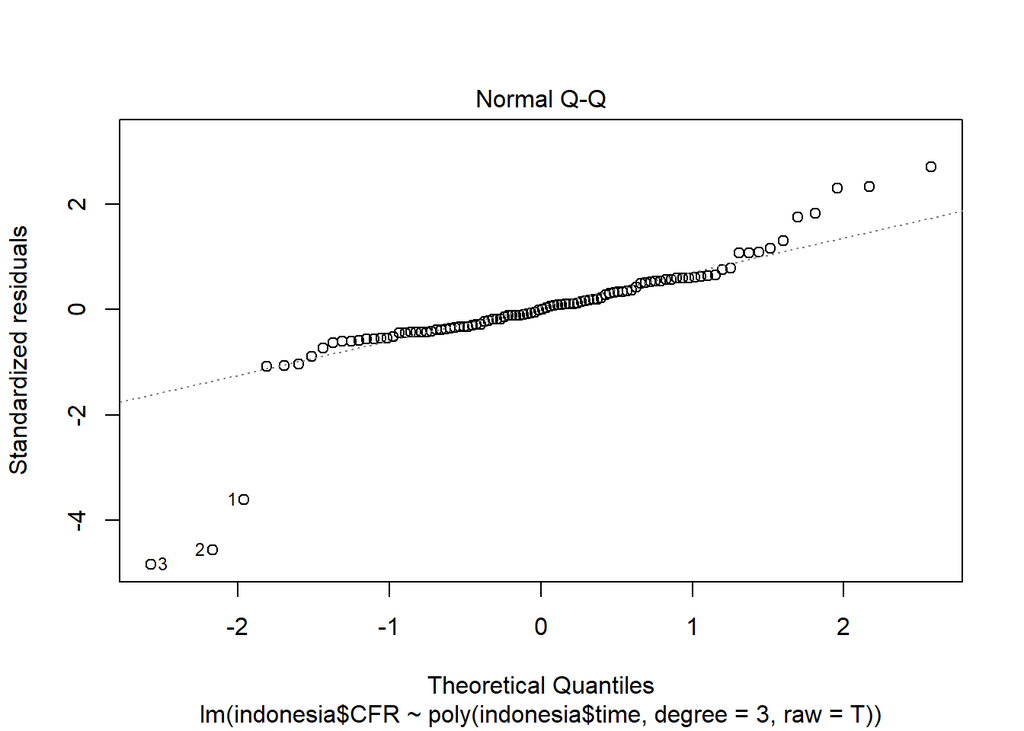

##Russia Plots

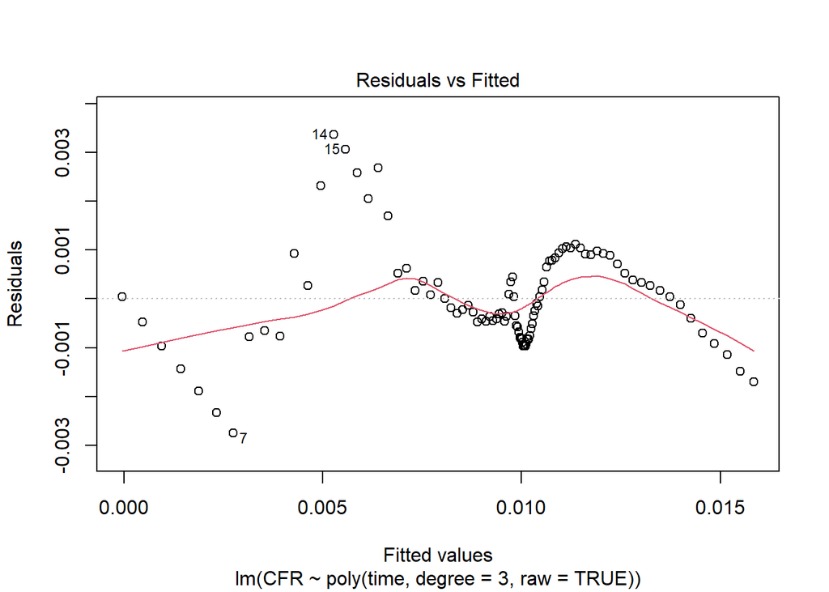

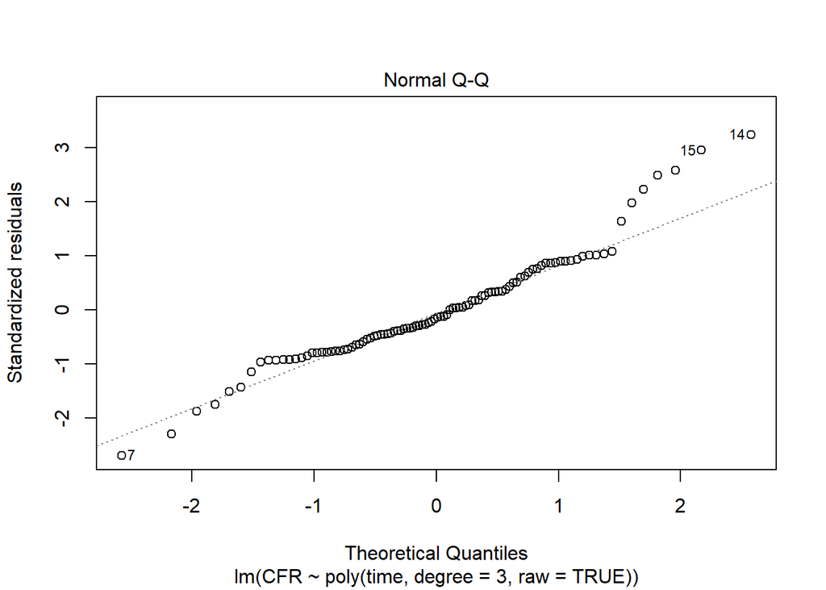

##Turkey Plots

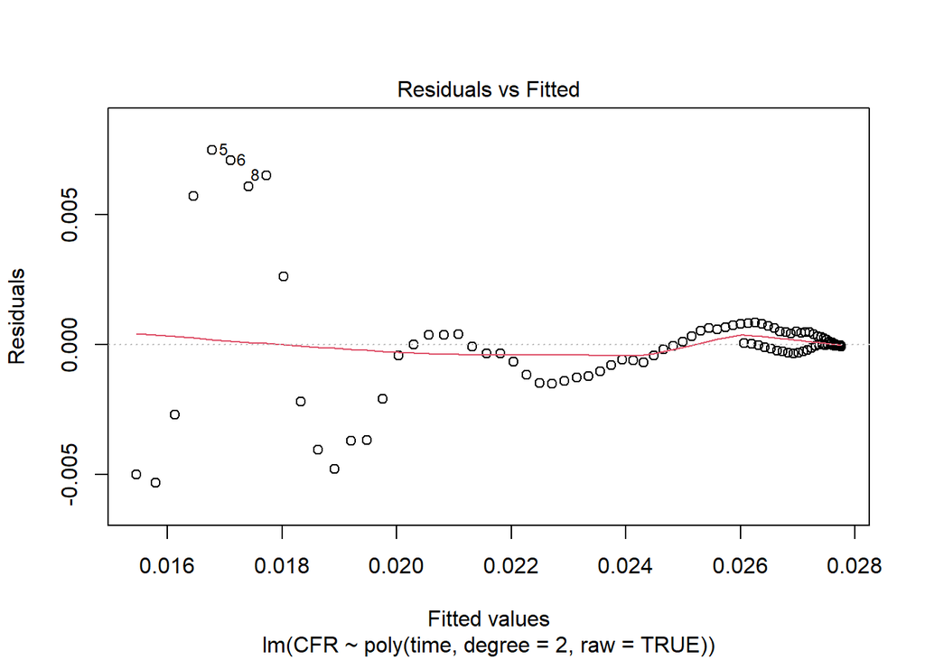

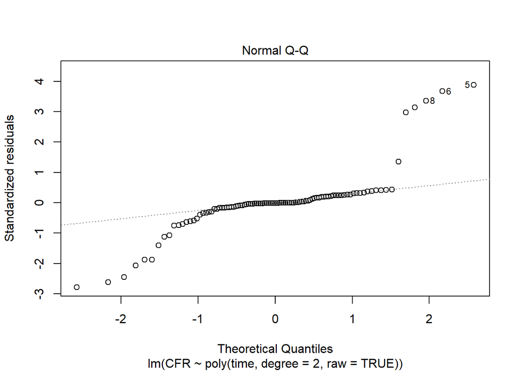

##Pakistan Plots

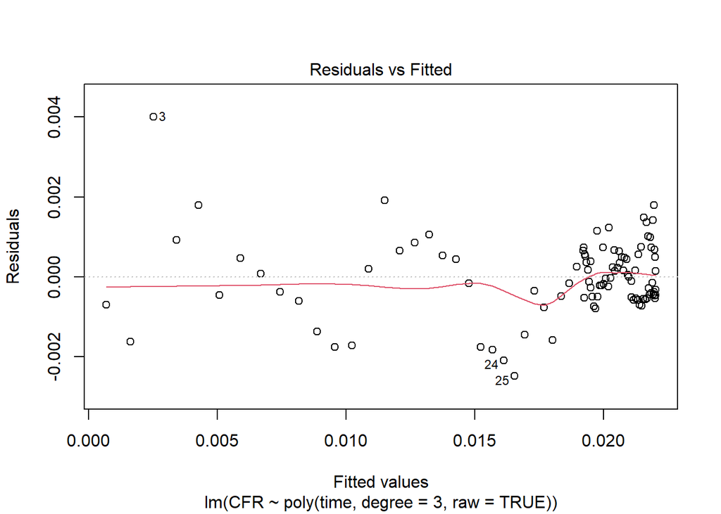

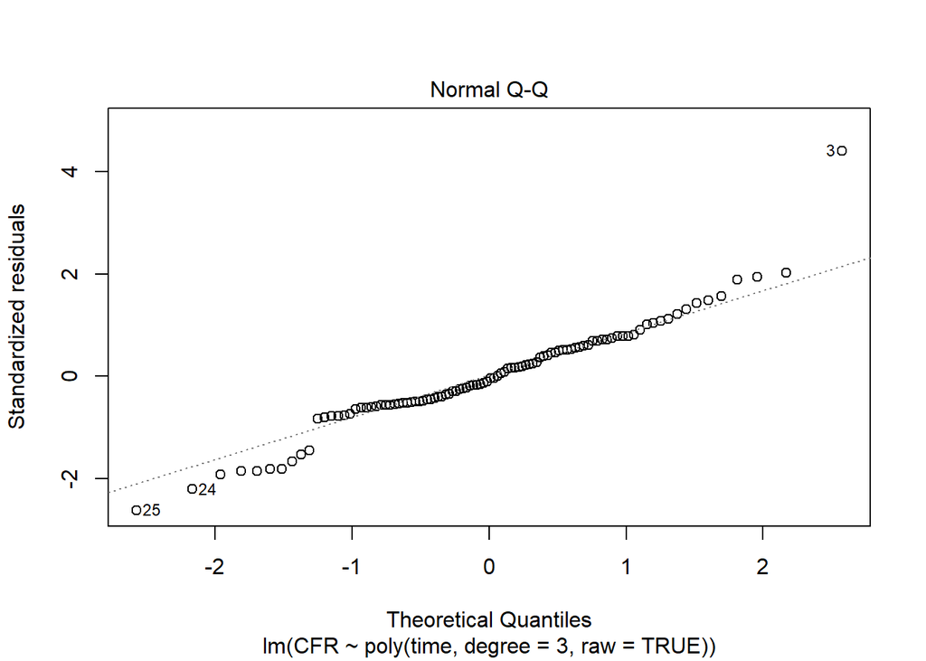

##Egypt Plots

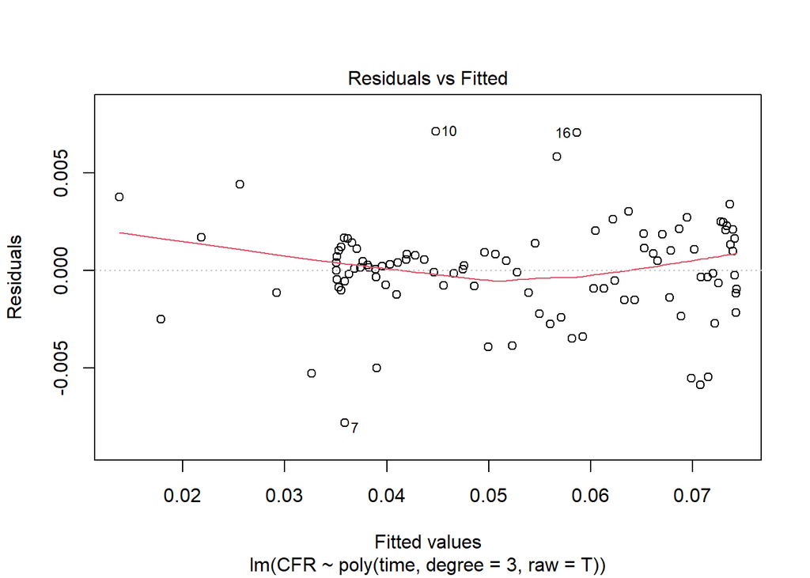

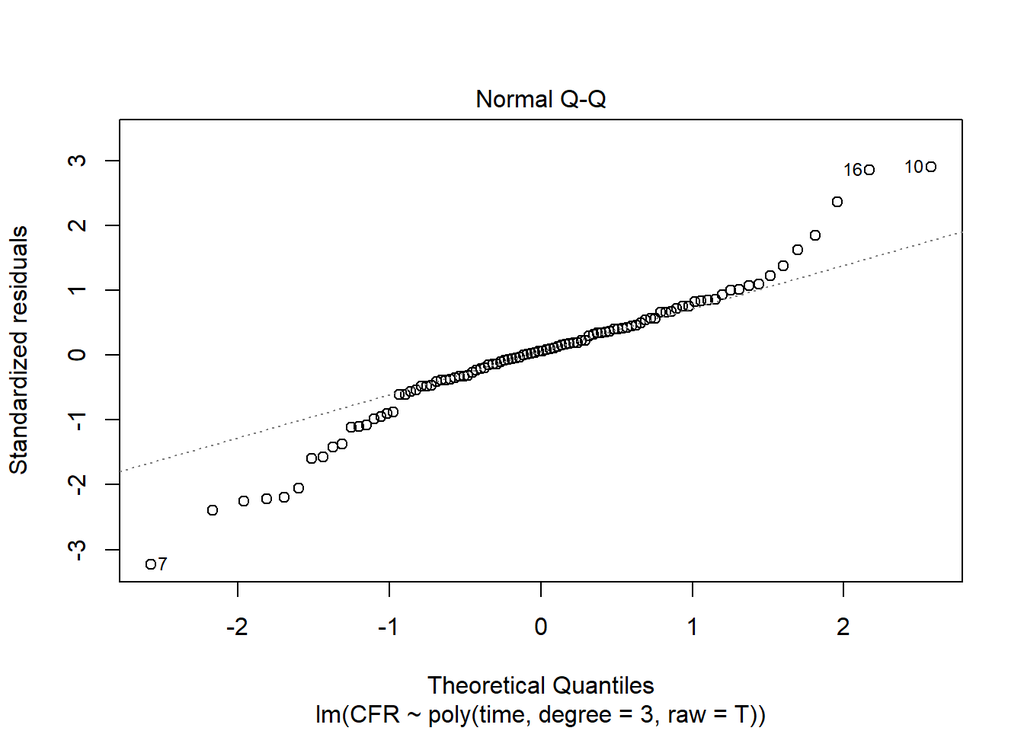

##China Plots

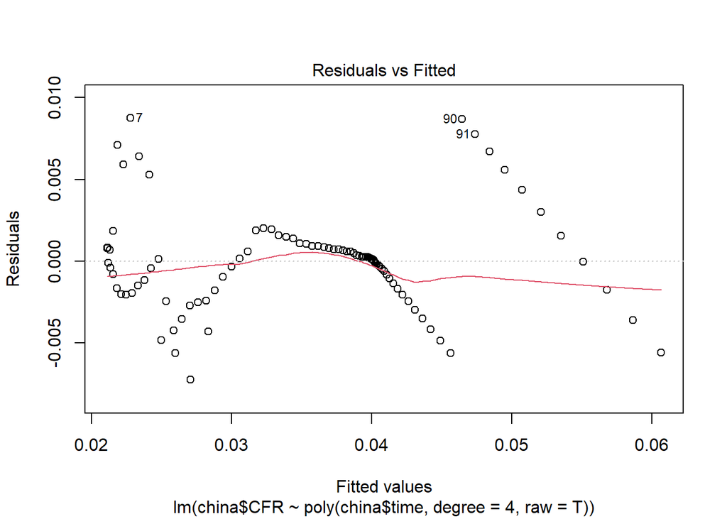

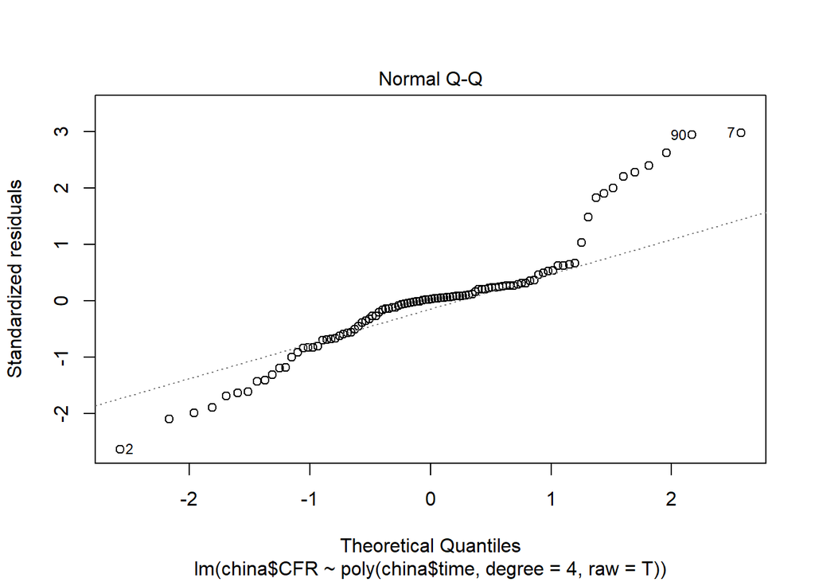

##Japan Plots

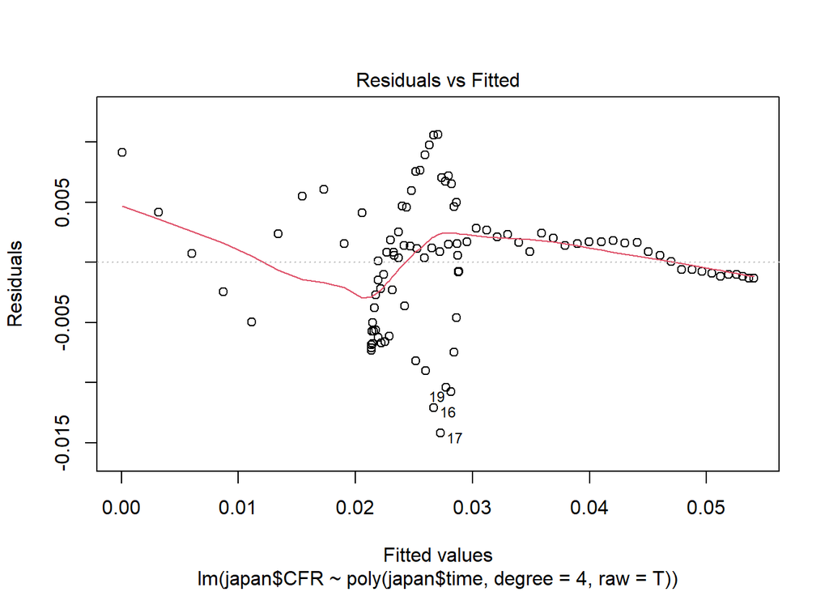

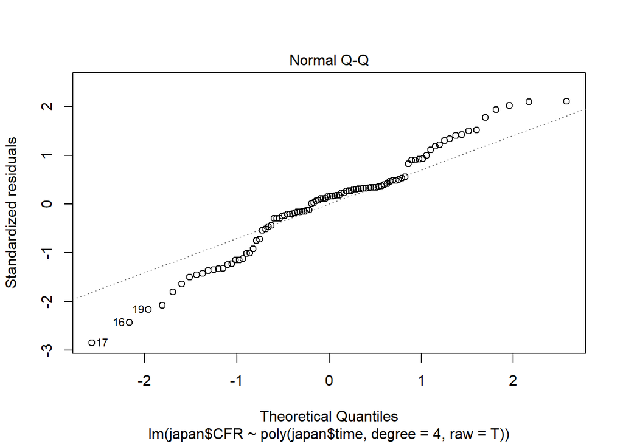

##ANOVA Plots

```
## Analysis of Variance Table
##
## Model 1: CFR ~ poly(time, 3)
## Model 2: CFR ~ poly(time, 3) * Country
##   Res.Df     RSS Df Sum of Sq      F    Pr(>F)
## 1   1196 0.48026
## 2   1152 0.01970 44   0.46057 612.15 < 2.2e-16 ***
## ---
## Signif. codes:  0 '***' 0.001 '**' 0.01 '*' 0.05 '.' 0.1 ' ' 1
```

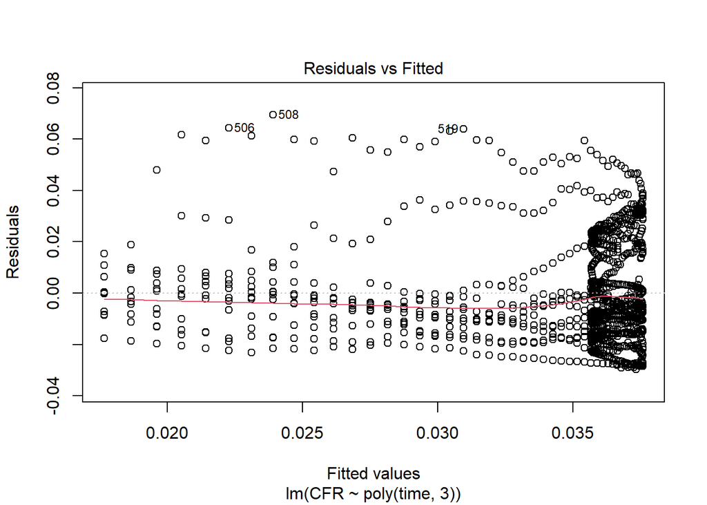

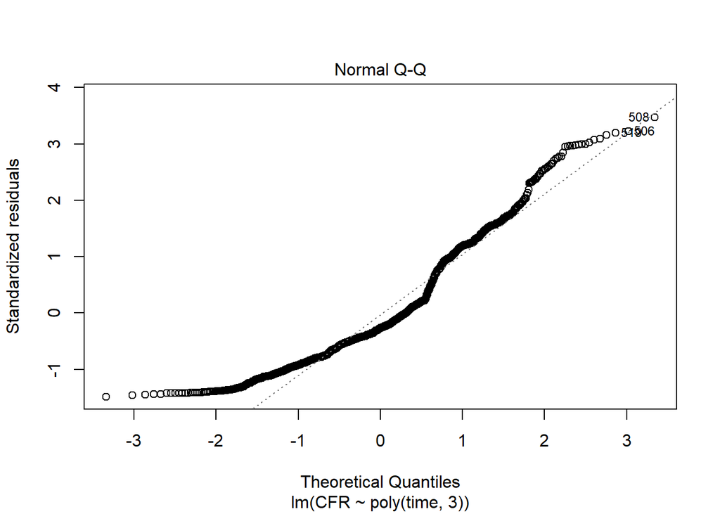

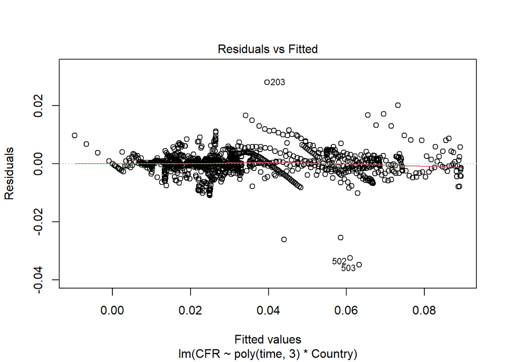

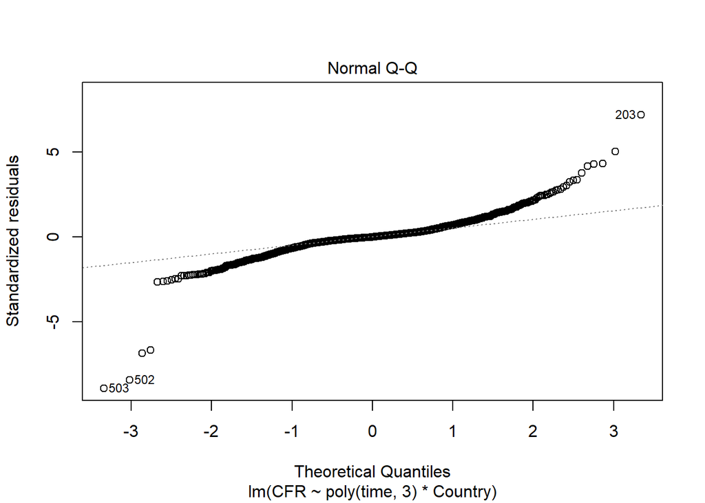

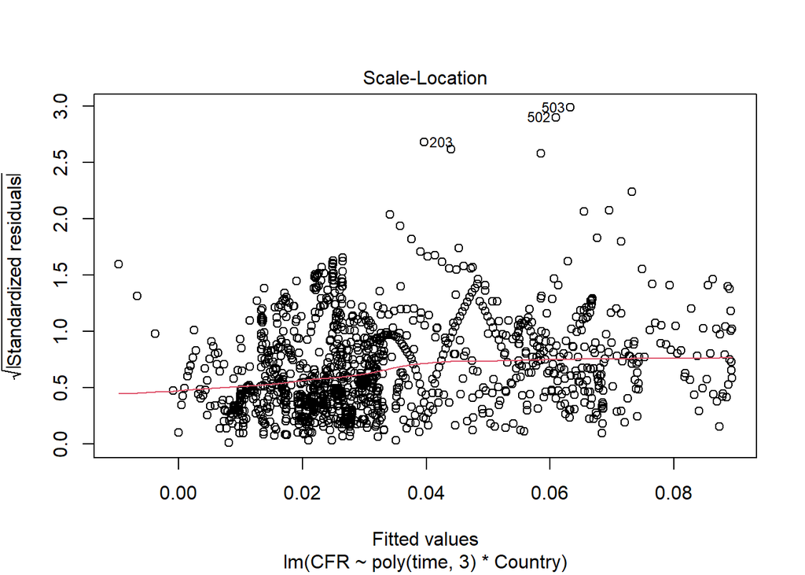

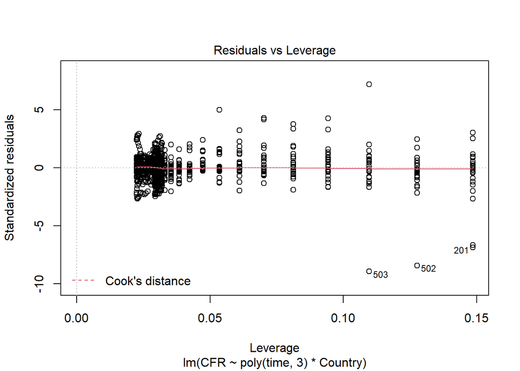

# Conclusion

This report aimed to investigate how Case Fatality Rate (CFR) for COVID-19 changes across time for 12 highly populated countries in the world (2 most populated countries per WHO region) over the first hundred days after the number of cumulative cases hits 100 in each country. Through a series of statistical analysis, this report was able to analyze the hypothesis stated earlier.

It was hypothesized that the trends of CFR will vary significantly across these countries. The results of this report aligned with the initial hypothesis. Through fitting the 12 observed countries’ CFR across time, a variety of regressions were chosen that best fits the data. These polynomial regressions vary in correlation and degree of polynomials, which visually supports the hypothesis that CFR across time will be different for the countries.

In order to be more specific and conduct a more detailed analysis, comparing the country’s regression lines side by side demonstrates the difference between countries’ CFR over time. The use of simultaneous confidence bands, which shows the 95% confidence interval across the whole regression line, appears even though some countries do share a similar trend and overlaps, the majority of regressions were very different from one another. Once again proving that CFR trends over time is different for each country.

Looking at these regressions may reflect how countries are able or not able to react in controlling the virus. It is observed that most CFR trends are fluctuating across the timeframe. A drop after a peak might be due to the implementation of a certain policy or a country gaining better knowledge on how to contain and treat the virus. While an increase after a trough may be hints of hitting medical capacity or loosening of policies. There are many external factors and reasons to explore beyond numbers of COVID cases and deaths. These are topics that can be delved deeper in further and more complicated analysis, however are all mere guesses at the current analysis.

The answer to the question of interest can be described as resounding and clear. However, it is important to note that this topic of interest has its own flaws and concerns to consider when interpreting the results. In terms of the dataset itself, the prevalence of reported cases and deaths varies between countries. This may be due to socioeconomic, political and cultural differences in each country. The number of observations for each country is limited, which amplifies the variance caused by outliers. Forming the question of interest was also based on a lot of logical assumptions that may not be statistically or scientifically true.

As the question of interest states, this report hopes to discover if there are significant differences in CFR over the first 100 days over a 100 cases. The regression lines for each country are in no intention to be predictive, rather to be a reflection of a specific trend during a specific time. The choice of countries and the choice of the timeframe are all factors to be aware of when interpreting the regressions. Unfair comparisons between countries may be made, for example a country that has a later time frame because of reaching hundred cases later may have better knowledge on the virus than countries that were affected earlier.

Overall, this report has been conclusive while assessed along with limitations. For further research, the reasons behind the trend can be explored, which could branch into a multitude of topics in politics, culture and science.

# References

Community mitigation framework. (2021, February 16). Retrieved March 05, 2021, from https://www.cdc.gov/coronavirus/2019-ncov/community/community-mitigation.html

Howard, J., Huang, A., Li, Z., Tufekci, Z., Zdimal, V., Westhuizen, H., . . . Rimoin, A. (2021, January 26). An evidence review of face masks against COVID-19. Retrieved March 05, 2021, from https://www.pnas.org/content/118/4/e2014564118

Sorci, G., Faivre, B., & Morand, S. (2020, November 03). Explaining among-country variation IN COVID-19 case fatality rate. Retrieved March 05, 2021, from https://www.nature.com/articles/s41598-020-75848-2#citeas

Tadiri, C. P., Gisinger, T., Kautzy-Willer, A., Kublickiene, K., Herrero, M. T., Raparelli, V., Pilote, L., Norris, C. M., & GOING-FWD Consortium (2020). The influence of sex and gender domains on COVID-19 cases and mortality. CMAJ : Canadian Medical Association journal = journal de l’Association medicale canadienne, 192(36), E1041–E1045. https://doi.org/10.1503/cmaj.200971

World Health Organization. (2021, March 1) WHO press conference on coronavirus disease (COVID-19) [Interview Transcript]. Retrieved from https://www.who.int/multi-media/details/who-press-conference-on-coronavirus-disease-(covid-19)---1-march-2021

Acknowledgements: We used course notes for STA 141A and material from discussion lectures to help compile this report. We also adapted code for confidence interval bands from the website below: https://stats.stackexchange.com/questions/231059/compare-the-statistical-significance-of-the-difference-between-two-polynomial-re